# A brief comparison of the distilled and full score statistics

Tim

2023-02-24

I programmed into `sceptre` both the distilled NB score statistic and the full NB score statistic. Here, I conduct a very preliminary investigation into the differences between the distilled and full score statistics. I find that the full score statistic appears to be more powerful than the distilled statistic on a randomly sampled set of 1,200 discovery pairs from the Papalexi data.

First, I load the `sceptre3` package.

```r
library(Matrix)
library(ggplot2)
library(sceptre3)
```

Next, I load the example data contained within the `sceptre` package. This is a subset of the Papalexi data.

```r
data(gene_matrix_lowmoi)
data(grna_matrix_lowmoi)
data(covariate_data_frame_lowmoi)
data(grna_group_data_frame_lowmoi)
data(response_grna_group_pairs_lowmoi)
```

I take a quick look at the data.

```r
gene_matrix_lowmoi[1:5, 1:5]
```

```
## 5 x 5 sparse Matrix of class "dgTMatrix"
##
## STAT3    5  2  . 1  3
## FCER1G   5 28 18 4 21
## MKLN1    1  .  2 .  .
## MRPS18C  .  .  1 .  .
## C11orf73 3  .  1 .  .
```

```r
grna_matrix_lowmoi[1:5, 1:5]
```

```
## 5 x 5 sparse Matrix of class "dgTMatrix"
##
## CUL3g1  . . . . .
## CUL3g2  . . . . .
## CUL3g3  . . . . .
## CMTM6g1 . . . . .
## CMTM6g2 . . . . .
```

```r
head(covariate_data_frame_lowmoi)
```

```
##   gene_n_umis gene_n_nonzero bio_rep phase     p_mito
## 1       17207           3942   rep_1    G1 0.02295577
## 2        9506           2948   rep_1    G1 0.04512939
## 3       15256           4258   rep_1    G1 0.04116413
## 4        5135           1780   rep_1    G1 0.05491723
## 5        9673           2671   rep_1    G1 0.03359868
## 6       14941           3918   rep_1    G1 0.03379961
```

```r
head(grna_group_data_frame_lowmoi)
```

```
##   grna_id grna_group
## 1  CUL3g1       CUL3
## 2  CUL3g2       CUL3
## 3  CUL3g3       CUL3
## 4 CMTM6g1      CMTM6
## 5 CMTM6g2      CMTM6
## 6 CMTM6g3      CMTM6
```

```r
head(response_grna_group_pairs_lowmoi)
```

```
##   grna_group response_id
## 1       CUL3       STAT3
## 2      CMTM6       STAT3
## 3       ATF2       STAT3
## 4       BRD4       STAT3
## 5       CAV1       STAT3
## 6       ETV7       STAT3
```

I constructed the example `response_grna_group_pairs_lowmoi` by pairing the entire set of gRNAs to a randomly selected set of 50 highly expressed genes. There are 1,200 pairs in total.

```r
response_matrix <- gene_matrix_lowmoi
grna_matrix <- grna_matrix_lowmoi
covariate_data_frame <- covariate_data_frame_lowmoi
grna_group_data_frame <- grna_group_data_frame_lowmoi
calibration_check <- FALSE
formula_object <- formula(~log(gene_n_umis) + log(gene_n_nonzero) + bio_rep + phase + p_mito)
response_grna_group_pairs <- response_grna_group_pairs_lowmoi
return_resampling_dist <- FALSE
adaptive_permutation_test <- TRUE
fit_skew_normal <- TRUE
B2 <- 25001L
```

I run `sceptre` on the data, initially setting the statistic to “distilled.” The function takes under 10 seconds to complete.

```r
system.time(result_dist <- run_sceptre_lowmoi(response_matrix,
                                  grna_matrix,
                                  covariate_data_frame,
                                  grna_group_data_frame,
                                  formula_object,
                                  calibration_check,
                                  response_grna_group_pairs,
                                  test_stat = "distilled",
                                  return_resampling_dist,
                                  adaptive_permutation_test,
                                  fit_skew_normal))
```

```
## Running setup.  ✓
## Generating permutation resamples. ✓
## Running the analysis.
## Analyzing pairs containing response STAT3 (1 of 50)
## Analyzing pairs containing response C11orf73 (5 of 50)
## Analyzing pairs containing response FKBP3 (10 of 50)
## Analyzing pairs containing response TRA2A (15 of 50)
## Analyzing pairs containing response ABCB10 (20 of 50)
## Analyzing pairs containing response PROCR (25 of 50)
## Analyzing pairs containing response DNAJC21 (30 of 50)
## Analyzing pairs containing response SERPINH1 (35 of 50)
## Analyzing pairs containing response RBPJ (40 of 50)
## Analyzing pairs containing response MYD88 (45 of 50)
## Analyzing pairs containing response PROSC (50 of 50)
```

```
##    user  system elapsed
##   7.950   0.219   8.200
```

```r
head(result_dist)
```

```
##    response_id grna_group    p_value log_fold_change      z_orig
## 1:       STAT3       CUL3 0.98804781     0.001041491  0.04119769
## 2:       STAT3      CMTM6 0.45019920     0.019508671  0.80196807
## 3:       STAT3       ATF2 0.56972112    -0.013142790 -0.65924357
## 4:       STAT3       BRD4 0.05976096     0.082840591  2.08089275
## 5:       STAT3       CAV1 0.55776892     0.010981321  0.50651940
## 6:       STAT3       ETV7 0.60557769     0.015819060  0.57046251
##    regression_method
## 1:      nb:resid_mle
## 2:      nb:resid_mle
## 3:      nb:resid_mle
## 4:      nb:resid_mle
## 5:      nb:resid_mle
## 6:      nb:resid_mle
```

Next, I run `sceptre` on the same data, this time setting the statistic to “full.” The function takes under 50 seconds to run.

```r
system.time(result_full <- run_sceptre_lowmoi(response_matrix,
                                  grna_matrix,
                                  covariate_data_frame,
                                  grna_group_data_frame,
                                  formula_object,
                                  calibration_check,
                                  response_grna_group_pairs,
                                  test_stat = "full",
                                  return_resampling_dist,
                                  adaptive_permutation_test,
                                  fit_skew_normal))
```

```
## Running setup.  ✓
## Generating permutation resamples. ✓
## Running the analysis.
## Analyzing pairs containing response STAT3 (1 of 50)
## Analyzing pairs containing response C11orf73 (5 of 50)
## Analyzing pairs containing response FKBP3 (10 of 50)
## Analyzing pairs containing response TRA2A (15 of 50)
## Analyzing pairs containing response ABCB10 (20 of 50)
## Analyzing pairs containing response PROCR (25 of 50)
## Analyzing pairs containing response DNAJC21 (30 of 50)
## Analyzing pairs containing response SERPINH1 (35 of 50)
## Analyzing pairs containing response RBPJ (40 of 50)
## Analyzing pairs containing response MYD88 (45 of 50)
## Analyzing pairs containing response PROSC (50 of 50)
```

```
##    user  system elapsed
##  48.570   0.524  49.281
```

```r
head(result_full)
```

```
##    response_id grna_group    p_value log_fold_change      z_orig
## 1:       STAT3       CUL3 0.98804781     0.001041491  0.04375025
## 2:       STAT3      CMTM6 0.45019920     0.019508671  0.92976331
## 3:       STAT3       ATF2 0.56972112    -0.013142790 -0.79779373
## 4:       STAT3       BRD4 0.05976096     0.082840591  2.26304464
## 5:       STAT3       CAV1 0.55776892     0.010981321  0.59243552
## 6:       STAT3       ETV7 0.60956175     0.015819060  0.66267560
##    regression_method
## 1:      nb:resid_mle
## 2:      nb:resid_mle
## 3:      nb:resid_mle
## 4:      nb:resid_mle
## 5:      nb:resid_mle
## 6:      nb:resid_mle
```

I plot the distilled vs. full p-values against one another on a negative log transformed scale.

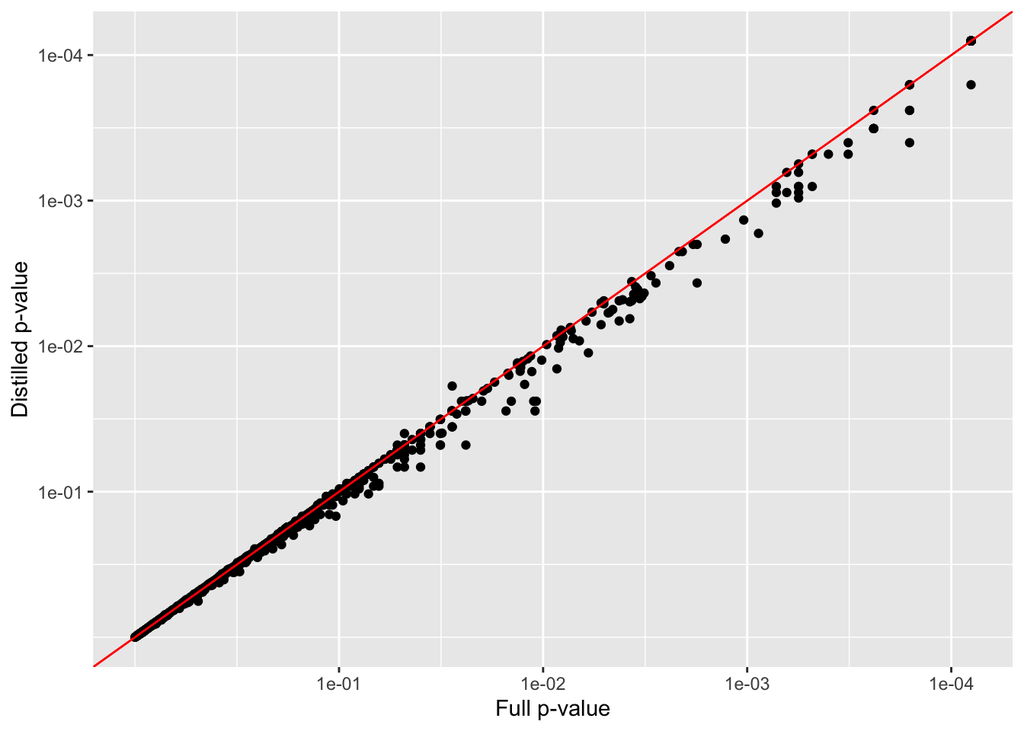

```r
x <- dplyr::left_join(x = result_full, y = result_dist,
                      by = c("response_id", "grna_group"), suffix = c("_full", "_dist"))
ggplot(data = x, mapping = aes(x = p_value_full, y = p_value_dist)) +
  geom_point() +
  scale_x_continuous(trans = katlabutils::revlog_trans(), breaks = c(0.1, 0.01, 0.001, 0.0001)) +
  scale_y_continuous(trans = katlabutils::revlog_trans(), breaks = c(0.1, 0.01, 0.001, 0.0001)) +
  geom_abline(slope = 1, intercept = 0, col = "red") +
  xlab("Full p-value") +
  ylab("Distilled p-value")
```

We see that the full p-values are generally smaller (i.e., more significant) than the distilled p-values in the tail. I apply a BH correction to the p-values and recreate the plot, this time plotting the adjusted p-values. I draw horizontal and vertical lines at 0.01.

```r
p_dist_adj <- p.adjust(p = x$p_value_dist, method = "BH")
p_full_adj <- p.adjust(p = x$p_value_full, method = "BH")
```

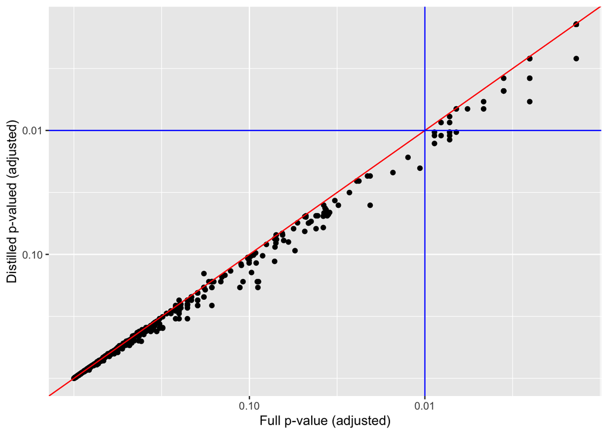

```r
ggplot(data = data.frame(p_dist_adj = p_dist_adj, p_full_adj = p_full_adj),
       mapping = aes(x = p_full_adj, y = p_dist_adj)) +
  geom_point() +
  scale_x_continuous(trans = katlabutils::revlog_trans(), breaks = c(0.1, 0.01)) +
  scale_y_continuous(trans = katlabutils::revlog_trans(), breaks = c(0.1, 0.01)) +
  geom_abline(slope = 1, intercept = 0, col = "red") +
  geom_vline(xintercept = 0.01, col = "blue") +
  geom_hline(yintercept = 0.01, col = "blue") +
  xlab("Full p-value (adjusted)") +
  ylab("Distilled p-valued (adjusted)")
```

I now compute the number of BH rejections made by each method.

```r
sum(p_dist_adj < 0.1)
```

```
## [1] 144
```

```r
sum(p_full_adj < 0.1)
```

```
## [1] 153
```

At FDR level 0.1, the full statistic makes 153 rejections, while the distilled statistic makes 144 rejections. This is an improvement of 6.3%.

```r
sum(p_dist_adj < 0.01)
```

```
## [1] 89
```

```r
sum(p_full_adj < 0.01)
```

```
## [1] 98
```

Recall from our undercover analyses that both the distilled statistic and the full statistic control type-I error on the negative control pairs. Thus, the boost in power that results from using the full statistic very likely is real (and not the result of type-I error inflation).

At some point it would be interesting to compare the full score statistic to the sum over Pearson residuals test statistic; the latter is commonly used in practice, whereas I believe that the former is novel. This probably can be relegated to a followup project.